# 01.06.00.00.RelatividadEspecial.MecanicaRelativista

Indice | Previo: RelatividadEspecial.CinematicaRelativista | Siguiente: RelatividadEspecial.ProblemasSeleccionados

## 1.12. Mecánica relativista

Hemos visto:

- Las transformaciones de Galileo-Newton no mantienen las ecuaciones de Maxwell covariantes.
- Para mantener las ecuaciones de Maxwell covariantes deben usarse las transformaciones de Lorentz-Einstein (TLE).
- Las TLE y sus conscuencias demuestran que la física debe hacerse en el espacio-tiempo de cuatro dimensiones y las cantidades físicas deben representarse como tensores (que transforman como las TLE) y las leyes como ecuaciones tensoriales.

¿Cómo se escriben las leyes de la mecánica en términos tensoriales? (en términos de invariantes). Llamaremos a la mecánica así construída **mecánica relativista**.

### 1.12.1. Masa invariante

El primer concepto central a la meánica relativista es el de **masa invariante**. Llamaremos así a la masa que asignamos a una partícula en un sistema de referencia que en un instante dado se mueve con la misma velocidad instantánea que ella. La masa invariante también se podría llamar **masa propia** siguiendo la convención semántica que habíamos usado hasta ahora.

Consideramos que esta es una cantidad verdaderamente escalar en el contexto del espacio-tiempo y por lo tanto que es una cantidad invariante, es decir, todos los observadores inerciales coincidiran en el valor de esta cantidad.

### 1.12.2. Momentum relativista

Si queremos formular una teoría mecánica relativista (covariante) debemos expresar todas las cantidades en términos de cantidades invariantes, cuadrivectores y tensores.

El momentum newtoniano:

$$ \vec p = m \vec v = m \frac{\mathrm{d}\vec{r}}{\mathrm{d}t} $$

claramente no es ni un cuadrivector, ni parte de él. La razón básica es que esta cantidad no transforma como $\mathrm{d}x^\mu$ que es nuestro cuadrivector prototipo.

Si definimos el momentum como:

$$ \vec p \equiv m \frac{\mathrm{d}\vec{r}}{\mathrm{d}\tau} $$

dado que $m$ y $\mathrm{d}\tau$ son invariantes, las componentes de este vector serán *parte* de un verdadero cuadrivector.

**Definición 1.12. Momentum relativista.** Una partícula que se mueve con velocidad $\vec v$ tiene un momento relativista:

> $$\vec p \equiv \gamma(v) m\vec v$$

Nótese que el momentum relativista coincide con el momentum clásico para $v\ll c$.

De aquí podemos postular:

**Postulado: Conservación del momentum relativista.** El momentum relativista total de un sistema aislado se mantiene constante. Es decir, en ausencia de fuerzas externas:

> $$\frac{\mathrm{d}}{\mathrm{d}\tau}\left(\sum \vec p_i\right) = \frac{\mathrm{d}}{\mathrm{d}\tau}\left(\sum \gamma(v_i) m_i\vec{v}_i\right)=0$$

Este postulado ha sido probado experimentalmente en incontables experimentos realizados en aceleradores de partículas.

**Nota: unidades luz de la masa y el momentum.** Como hemos venido trabajando en unidades luz todas las cantidades cinemáticas, es interesante preguntarse por cuáles son las unidades del momentm. Tal y como es definido el momentum en unidades convencionales y el momentum en unidades luz se relacionaran como:

> $$\vec{p} = c\vec{p}_L$$

A velocidades intermedias y conservando los términos de orden $v_L^3$ la magnitud del momentum relativista es:

$$ p_L \approx m v_L + \frac{1}{2} m v_L^3 $$

Este segundo término no se conocía en el mundo clásico.

En el algoritmo abajo mostramos el momentum relativista de una partícula como función de su velocidad.

```python
%matplotlib inline
```

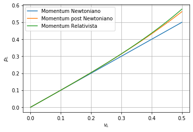

```python
from numpy import linspace
vLs=linspace(0,0.5,100)
gammas=1/(1-vLs**2)**0.5
m=1

import matplotlib.pyplot as plt
fig=plt.figure()
ax=fig.gca()

pLs_new=m*vLs
pLs_rel=gammas*m*vLs
pLs_apr=m*vLs+0.5*m*vLs**3

ax.plot(vLs,pLs_new,label="Momentum Newtoniano")
ax.plot(vLs,pLs_apr,label="Momentum post Newtoniano")
ax.plot(vLs,pLs_rel,label="Momentum Relativista")

ax.set_xlabel("$v_{L}$")
ax.set_ylabel("$p_{L}$")
ax.legend()
ax.grid();
```

**Figura 1.17.**

**Nota: masa relativística.** Una interpretación *clásica* del momentum relativístico es decir que lo que sucede cuando una partícula se mueve su masa aumenta siguiendo la prescripción:

> $$m_r = \frac{m}{\sqrt{1-v_L^2}}$$

> donde $m_r$ se conoce como la **masa relativística**. La mayoría de los autores consideran hoy esta interpretación como conceptualmente imprecisa sino incorrecta. Hay varias razones para ello, siendo la más importante el hecho que siendo $m$ un escalar no asociado a ninguna cantidad geométrica, no existe una justificación de porque debería transformar como se indica arriba.

> Adicionalmente si vemos la expresión para el momentum post Newtoniano: $$p_L \approx m v_L + \frac{1}{2} m v_L^3$$ notamos que en realidad el aumento de $p_L$ con la velocidad, por encima del valor newtoniano $m v_L$ es producto de los términos que no habían sido *descubiertos* y no del aumento en la masa.

### Energía cinética relativistica

El momentum relativista nos sirve para definir otras cantidades útiles. En mecánica clásica el teorema del trabajo y la energía establece que:

$$ K=\int_{0}^{\vec r} \vec F\cdot \mathrm{d}\vec{r} $$

En esta expresión $\mathrm{d}\vec r$ es parte de un cuadrivector, pero la fuerza clásica $\vec F$ no lo es.

Una forma más conveniente de escribir esta expresión clásicamente es identificando: $$\vec F\cdot \mathrm{d}\vec r = \vec v\cdot \mathrm{d}\vec p$$

Escribiendo la energía cinética de este modo:

$$ K=\int \vec v\cdot \mathrm{d}\vec p $$

**Postulado: Postulado de la energía cinética.** La energía cinética relativista (covariante) se relaciona con el momentum relativista como:

> $$k\equiv\int_0^{\vec v} \vec v\cdot \mathrm{d}\vec p$$

> o en unidades luz: $$k_L\equiv\int_0^{\vec v_L} \vec v_L\cdot \mathrm{d}\vec p_L$$

> Por la definición de la energía cinética relativista, la relación entre esta cantidad expresada en unidades luz y la misma cantidad expresada en unidades convencionales es:

> $$k = c^2 k_L$$

¿Cómo se expresa la energía cinética explícitamente como función de la velocidad?. En la mecánica Newtoniana sabemos que:

$$ K=\frac{1}{2}mv^2 $$

**Nota: cambio de mayúsculas por minúsculas en mecánica relativista.** Es corriente cambiar las letras que usamos para las cantidades mecánica de acuerdo a si son las clásicas (newtonianas) o las relativísticas. Normalmente, si una cantidad se representa con una letra minúscula en la mecánica newtoniana, se representará con una letra mayúscula en la mecánica relativista y viceversa. Existen, naturalmente, algunas excepciones notables. A continuación se enumeran estas *transformaciones* de notación:

> $$ \begin{array}{rcl} \mathrm{Mecánica\;Newtoniana} & \rightarrow & \mathrm{Mecánica\;Relativista}\\ \vec v & \rightarrow & U^\mu\;\mathrm{(cuadrivelocidad)} \\ \vec a & \rightarrow & A^\mu\;\mathrm{(cuadriaceleración)} \\ m & \rightarrow & m\;\mathrm{(masa\;invariante)} \\ \vec p & \rightarrow & \vec p\;\mathrm{(trimomentum)}\\ \vec p & \rightarrow & P^\mu\;\mathrm{(cuadrimomentum)}\\ k & \rightarrow & K\;\mathrm{(energía\;cinética\;relativista)}\\ E & \rightarrow & E\;\mathrm{(energía\;total\;relativista)}\\ \vec F & \rightarrow & f^\mu\;\mathrm{(cuadrifuerza)}\\ \end{array} $$

Reemplazando la definición del momentum relativista en la definición de energía cinética:

$$ k_L=\int_0^{\vec v_L} \vec v_L\cdot m\;\mathrm{d}\left(\frac{\vec v_L}{\sqrt{1-v_L^2}}\right) $$

Integrando por partes obtenemos:

$$ k_L=(\gamma-1)m $$

o en unidades convencionales

$$ k=(\gamma-1)mc^2 $$

Expandiendo $\gamma-1$:

$$ k_L\approx \frac{1}{2}m v_L^2 $$

que coincide con lo que sabemos en mecánica Newtoniana.

### Energía total relativista

Una manera de escribir la energía cinética es:

$$ k_L = \gamma m - m $$

o en unidades convencionales:

$$ k = \gamma(v) m c^2 - \gamma(0) m c^2 $$

donde hemos usado el hecho de que $\gamma(0)=1$.

Estas dos expresiones dan la idea de que cuando sobre una partícula se realiza un trabajo (igual a $k$) una cantidad asociada con la partícula cambia de valor. No importa la naturaleza del trabajo realizado, siempre esa cantidad cambia de valor. La cantidad es:

$$ E=\gamma m c^2 $$

o en unidades luz:

$$ E_L=\gamma m $$

¿Qué tiene de especial esta cantidad?. Puede mostrarse (ver Problemas al final del capítulo) que esta cantidad se conserva.

**Proposición. Conservación de la energía total relativista**. Dado un sistema aislado formado por partículas de masas invariantes $\{m_i\}$ que se mueven con velocidades instantáneas $\{\vec{v}_i\}$ que pueden cambiar en el tiempo como resultado de su mutua interacción, entonces la cantidad:

> $$E\equiv \sum_i (k_i+m_i c^2) = \sum_i \gamma (v_i) m_i c^2$$

> es constante. Llamaermos a $E$ la **energía total** del sistema.

> En unidades luz: $$E_L \equiv \sum_i \gamma (v_{Li}) m_i$$

### 1.12.3. Cuadrimomentum

Hasta ahora todas las cantidades mecánicas definidas son cantidades vectoriales (trivectores) o escalares. Sin embargo para formular leyes físicas covariantes, estas deben escribirse rigurosamente en términos de tensores.

Existe una poderosa simetría en relatividad que emerge de las relaciones anteriores.

Nótese que hemos postulado y demostrado la conservación de dos cantidades claves:

- Momentum relativista: $\vec p_L=\gamma m \vec v_L$
- Energía relativista: $E_L = \gamma m$

¿Podrían estas dos cantidades usarse para definir una única cantidad conservada en 4 dimensiones?. Es fácil ver que si definimos la cantidad:

$$ P_L^\mu : (E_L,\vec p_L) $$

las componentes de esta cantidad serán conservadas y por lo tanto la cantidad cuadrivectorial será conservada también.

En términos de la masa invariante y la velocidad la cantidad se escribe:

$$ P_L^\mu : m \gamma (1,\vec v_L) $$

pero identificamos aquí a la cuadrivelocidad $U_L^\mu :\gamma(1,\vec v_L)$ y por lo tanto podemos escribir:

$$ P_L^\mu = m U_L^\mu $$

> **Proposición: Conservación del cuadrimomentum**. Si en un sistema aislado definimos el cuadrimomentum como:

> $$P^\mu_L \equiv \sum_i m_i U^\mu_{iL}$$

> entonces esta cantidad se mantiene constante. El cuadrimomentum de cada partícula tiene componentes: $$P^\mu_{iL}:(E_{iL},\vec p_{iL})$$ o en unidades convencionales: $$P^\mu_i:(E/c,\vec{p}_i)$$

### 1.12.4. Magnitud del cuadrimomentum y la simetría gauge

¿Cuál era la simetría de la que hablabamos antes?. La magnitud del cuadrimomentum es por definición:

$$ |P^\mu_L|^2=|m U^\mu_L|^2=m^2 $$

y por componentes:

$$ |P^\mu_L|^2=E_L^2 - p_L^2 $$

De aquí se sigue la relación fundamental:

$$ m^2= E_L^2 - p_L^2 $$

o en unidades convencionales:

$$ m^2= E^2/c^4 - p^2/c^2 $$

que se escribe tradicionalmente como:

$$ (mc^2)^2= E^2 - (pc)^2 $$

**Nota: La masa como una cantidad geométrica.** Vemos que el cuadrimomentum ofrece una interesante interpretación para la masa. La masa como la magnitud del cuadrimomentum. Esto explica su invarianza (los módulos son invariantes geométricos). Sin embargo debe entenderse que la masa como módulo del cuadrimomentum es *resultado* de asumir que es una cantidad invariante y no al revés.

Esta relación es increíble porque abre la posibilidad para que las partículas tengan masa nula. Si

$$ E_L=p_L $$

o lo que es lo mismo, en unidades convencionales:

$$ E/c^2 = p/c $$

o bien

$$ E=pc $$

entonces la partícula tendrá masa nula.

Esta última relación es conocida en el electromagnetismo y es la relación entre la energía y el momentum transportado por una onda electromagnética. Es decir, podemos asociar a las ondas electromagnéticas masa nula. En la moderna teoría cuántica de campos a esta condición se la llama **simetría gauge**.

### 1.12.5. Cuadrimomentum en el espacio-tiempo

La relación entre la masa, la energía y el momentum, muestra una propiedad muy interesante en el espacio-tiempo. Si construimos un espacio con coordenadas $E_L$ y $p_{Lx}$ (espacio energía-momentum) entonces la ecuación de la masa indica que no importa el estado de movimiento en el que se encuentre una partícula siempre estará sobre una hipérbola en este espacio.

Si usamos el hecho:

$$ E_L^2=m^2 + p_{Lx}^2 $$

podemos hacer una gráfica del lugar geométrico del cuadrimomentum en el espacio energía-momentum para distintas velocidades.

```python
%matplotlib inline
```

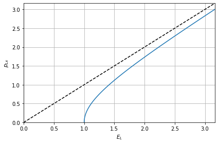

```python
#Masa de la partícula
m=1 # kg

#Momenta y energías
from numpy import linspace,sqrt
pLs=linspace(0,3)
ELs=sqrt(m**2+pLs**2)

#Gráfico
import matplotlib.pyplot as plt
fig=plt.figure()
ax=fig.gca()

ax.plot(ELs,pLs)

#Decoración
rang=ELs.max()
ax.set_xlim((0,rang))
ax.set_ylim((0,rang))
ax.plot([0,rang],[0,rang],'k--')
ax.set_xlabel("$E_L$");
ax.set_ylabel("$p_{Lx}$");
ax.grid();
fig.tight_layout();
```

**Figura 1.18.**

Indice | Previo: RelatividadEspecial.CinematicaRelativista | Siguiente: RelatividadEspecial.ProblemasSeleccionados